# CST Typing by DESI-MS - metabolic signals associated with community state types - Linear mixed effect model analysis

Load the required packages

# Data import

Load the VMET2 DESI-MS Positive and Negative mode datasets

Load the VMET DESI-MS Positive and Negative mode datasets

Overview of final dataset dimensions

```r
# VMET2 DESI-MS Negative Mode
cat(paste("VMET2 DESI-MS Negative Mode Matrix: ", dim(desi_neg_vmet2)[1], "samples, ", dim(desi_neg_vmet2)[2] - 29, "metabolic features", "\n"))
```

```
VMET2 DESI-MS Negative Mode Matrix:  539 samples,  1924 metabolic features
```

```r
# Assign a variable with the index of the first column corresponding to an MS signal
desineg_first_metabolite_idx_vmet2 <- 29

# VMET2 DESI-MS Positive Mode
cat(paste("VMET2 DESI-MS Positive Mode Matrix: ", dim(desi_pos_vmet2)[1], "samples, ", dim(desi_pos_vmet2)[2] - 29, "metabolic features", "\n"))
```

```
VMET2 DESI-MS Positive Mode Matrix:  545 samples,  1715 metabolic features
```

```r
# Assign a variable with the index of the first column corresponding to an MS signal
desipos_first_metabolite_idx_vmet2 <- 29

# VMET DESI-MS Negative Mode
cat(paste("VMET DESI-MS Negative Mode Matrix: ", dim(desi_neg_vmet)[1], "samples, ", dim(desi_neg_vmet)[2] - 28, "metabolic features", "\n"))
```

```
VMET DESI-MS Negative Mode Matrix:  428 samples,  1332 metabolic features
```

```r
# Assign a variable with the index of the first column corresponding to an MS signal
desineg_first_metabolite_idx_vmet <- 28

# VMET DESI-MS Positive Mode
cat(paste("VMET DESI-MS Positive Mode Matrix: ", dim(desi_pos_vmet)[1], "samples, ", dim(desi_pos_vmet)[2] - 28, "metabolic features", "\n"))
```

```
VMET DESI-MS Positive Mode Matrix:  412 samples,  1554 metabolic features
```

```r
# Assign a variable with the index of the first column corresponding to an MS signal
desipos_first_metabolite_idx_vmet <- 28
```

# Main Linear mixed effect model structure and contrasts

In this notebook, we will define a general mixed effect model formula to model metabolite variability as function of Community State Type, (CST), gestational age, maternal BMI, maternal age, ethnicity, with random effects (slope with gestational age and intercept for baseline differences) to account for between individual variability.

Example LME Model definition and summary

```r
# Select a random feature from VMET2
currmet <- colnames(desi_neg_vmet2)[1085]

# metabolite variability explained as a function of CST, GestationalAge,
# BMI and Ethnicity, with random intercept and slope (GestationalAge) per patient
rsmodel <- lmer(log(get(currmet) + 1) ~ CST + GestationalAge +  BMI + Ethnicity + Age + (0 + GestationalAge|SubjectID) + (1|SubjectID), data=desi_neg_vmet2,  REML=TRUE)

# Default model summmary
summary(rsmodel, ddf='Kenward-Roger')
```

[output not shown]

Example of contrast coding for the model fitted in the last cell.

```r
cst_pairwise_contrasts <- data.frame(emmeans(rsmodel, pairwise~CST, at=list(GestationalAge=20, Age=30, BMI=25), adjust='None')$contrast)

gestage_contrasts <- data.frame(emmeans(rsmodel, revpairwise ~ GestationalAge, at=list(GestationalAge=c(8, 36), BMI=25, Age=20), adjust='None')$contrast)

cst_means <- emmeans(rsmodel, 'CST',  at=list(GestationalAge=20, Age=30, BMI=25))

lactobacillusDepleted <- data.frame(contrast(cst_means, list(LDepleted=c(-1/5, -1/5, -1/5, 1/2, -1/5, 1/2, -1/5)),                                 at=list(GestationalAge=20, Age=30, BMI=25),  adjust='None'))
```

## Linear mixed effect modelling of the VMET2 Dataset

In the next cell we define an utility function which fits a linear mixed model for a single metabolic feature and retrieves the main estimates and p-values. This function will be applied in parallel to all variables in a DESI-MS dataset. This version of the function is tailored for the VMET2 cohort metadata naming conventions. Model is adjusted for CST, GestationalAge, BMI, Ethnicity and Age, with a random slope and intercept per individual. Contrasts for differences between CSTs, including LDominant (average of I, II, III, V) vs LDepleted CST (IV) are calculated for mid-Gestation (20 weeks), with maternal age = 30, BMI=25 and averaged over all Ethnicity levels. Comparisons between early and late gestation (36 vs 8 weeks) are also calculated, with maternal age=30, BMI=25 and averaged over all Community State Types and Ethnicity levels.

```r
fit_lmm_beta_and_pvalues_vmet2 <- function(dataset, var) {
    #
    tryCatch({
      currmet <- colnames(dataset)[var]

      # LME model were GestationalAge is modelled as a time slope. Random intercept and slope per patient
      rsmodel <- lmer(log(get(currmet) + 1) ~ CST + GestationalAge + BMI + Ethnicity + Age + (GestationalAge||SubjectID), data=dataset,  REML=TRUE)

      cst_pairwise_contrasts <- data.frame(emmeans(rsmodel, pairwise~CST, at=list(GestationalAge=20, Age=30, BMI=25), adjust='None')$contrast)

      gestage_contrasts <- data.frame(emmeans(rsmodel, revpairwise ~ GestationalAge, at=list(GestationalAge=c(8, 36), BMI=25, Age=30), adjust='None')$contrast)

      cst_means <- emmeans(rsmodel, 'CST',  at=list(GestationalAge=20, Age=30, BMI=25))

      lactobacillusDepleted <- data.frame(contrast(cst_means, list(LDepleted=c(-1/4, -1/4, -1/4, 1, -1/4, 0, 0)),                                 at=list(GestationalAge=20, Age=30, BMI=25), djust='None'))

       pvalues <- c(cst_pairwise_contrasts[, 6], lactobacillusDepleted[, 6], gestage_contrasts[, 6])
       tvalues <- c(cst_pairwise_contrasts[, 5], lactobacillusDepleted[, 5], gestage_contrasts[, 5])

       contrast_names <- c(as.character(cst_pairwise_contrasts[ ,1]), as.character(lactobacillusDepleted[, 1]), as.character(gestage_contrasts[, 1]))

       contrast_pval_names <- lapply(contrast_names, FUN=function(x) {paste(x, '_pval')})
       contrast_tval_names <- lapply(contrast_names, FUN=function(x) {paste(x, '_t.ratio')})

       res_frame <- data.frame(cbind(substring(currmet, first=2), t(pvalues), t(tvalues)))
       colnames(res_frame) <- c("Metabolite", contrast_pval_names, contrast_tval_names)

       return(res_frame)

       }, error = function(err){stop()})
}
```

## VMET2 dataset - Linear Mixed Models

Run the Linear Mixed Effects models in the VMET2 DESI-MS Positive mode data

```r
lme_desi_pos_vmet2 <- foreach(var=desipos_first_metabolite_idx_vmet2:length(desi_pos_vmet2), .combine=rbind) %dopar% {
    tryCatch({
        return(fit_lmm_beta_and_pvalues_vmet2(desi_pos_vmet2, var))
    }, error = function(err) {
       # In case of crash fill a row of NA's
       currmet_parsed <- substring(colnames(desi_pos_vmet2)[var], first=2)
       return(c(currmet_parsed, rep(NA,46)))
    })
}
```

[output not shown]

[output cut: 11230 more lines]

[output not shown]

```r
lme_desi_pos_vmet2[2:dim(lme_desi_pos_vmet2)[2]] <- apply(lme_desi_pos_vmet2[, 2:dim(lme_desi_pos_vmet2)[2]], FUN = function(x) {as.numeric(as.character(x))}, 2)

write.csv(lme_desi_pos_vmet2, './LinearMixedModels_DESI-MS/VMET2_DESI_POS_LME_CST.csv')
# Apply Benjamini-Hochberg FDR correction at "contrast"/comparison level
corrected_desi_pos_vmet2 <- cbind(Metabolite=as.numeric(as.character(lme_desi_pos_vmet2[, 1])), apply(lme_desi_pos_vmet2[, 2:24], 2, p.adjust, method='BH'))

write.csv(corrected_desi_pos_vmet2 , './LinearMixedModels_DESI-MS/VMET2_DESI_POS_LME_CST_BH.csv')
```

Run the Linear Mixed Effects models in the VMET2 DESI-MS Negative mode data

## Linear mixed effect modelling of the VMET Dataset

```r
fit_lmm_beta_and_pvalues_vmet <- function(dataset, var) {

    tryCatch({

    currmet <- colnames(dataset)[var]

    # LME model were GestationalAge is modelled as a time slope. Random intercept and slope per patient
    rsmodel <- lmer(log(get(currmet) + 1) ~ CST + GestationalAge +  BMI + Ethnicity  + (GestationalAge||SubjectID),
                    data=dataset,  REML=TRUE)

    cst_pairwise_contrasts <- data.frame(emmeans(rsmodel, pairwise~CST,
                                                  at=list(GestationalAge=20,  BMI=25), adjust='None')$contrast)
    gestage_contrasts <- data.frame(emmeans(rsmodel, revpairwise ~ GestationalAge,
                                            at=list(GestationalAge=c(8, 36), BMI=25), adjust='None')$contrast)

    cst_means <- emmeans(rsmodel, 'CST',  at=list(GestationalAge=20, BMI=25))

    lactobacillusDepleted <- data.frame(contrast(cst_means, list(LDepleted=c(-1/4, -1/4, -1/4, 1, -1/4, 0)),
                                                             at=list(GestationalAge=20, BMI=25),
                                                             adjust='None'))

    pvalues <- c(cst_pairwise_contrasts[, 6], lactobacillusDepleted[, 6], gestage_contrasts[, 6])
    tvalues <- c(cst_pairwise_contrasts[, 5], lactobacillusDepleted[, 5], gestage_contrasts[, 5])

    contrast_names <- c(as.character(cst_pairwise_contrasts[ ,1]), as.character(lactobacillusDepleted[, 1]), as.character(gestage_contrasts[, 1]))

    contrast_pval_names <- lapply(contrast_names, FUN=function(x) {paste(x, '_pval')})
    contrast_tval_names <- lapply(contrast_names, FUN=function(x) {paste(x, '_t.ratio')})

    res_frame <- data.frame(cbind(substring(currmet, first=2), t(pvalues), t(tvalues)))
    colnames(res_frame) <- c("Metabolite", contrast_pval_names, contrast_tval_names)

    return(res_frame)

    }, error = function(err){stop()})
}
```

Run the Linear Mixed Effects modeling in the VMET DESI-MS Positive mode VMET data

Run the Linear Mixed Effects models in the VMET DESI-MS Negative mode VMET data

## Example box-and-whiskers plots for some of the features. This code can be used to generate the box-and-whiskers plot seen in Figure 1.

```r
# For Figure 1's box-and-whiskers plots use these masses:
# 1 - Thiomalic acid VMET : X148.9915298 VMET2 :X48.9914757
# 2 - Isoleucyl-Serine VMET: X217.1195514 VMET2 : X217.1195277
# 3 - Lignoceric acid (C24:0) VMET: X367.358036 VMET2 : X367.3580571
# 4 - Docosanoic acid (C22:0) VMET: X339.3269748 VMET2 : X339.3268408
#
vmet_feature <- "X148.9915298"
vmet2_feature <- "X148.9914757"

vmet_intensity <- scale(as.numeric(desi_neg_vmet[, vmet_feature]), center=T)
vmet2_intensity <- scale(as.numeric(desi_neg_vmet2[, vmet2_feature]), center=T)

boxplot_DFrame <- data.frame(cbind(LDominant=c(desi_neg_vmet$LDominant_CST, desi_neg_vmet2$LDominant_CST),
                                   Intensity=c(vmet_intensity, vmet2_intensity)),
                                   CST=c(desi_neg_vmet$CST, desi_neg_vmet2$CST),
                                   SubjectID=c(desi_neg_vmet$SubjectID, desi_neg_vmet2$SubjectID),
                                   Study=c(rep('VMET', dim(desi_neg_vmet)[1]), rep('VMET2', dim(desi_neg_vmet2)[1])))

feature_box_plot <- ggplot(boxplot_DFrame, aes(x=Study, y=as.numeric(as.character(Intensity)))) + geom_boxplot(aes(fill=LDominant), outlier.shape=NA, alpha=0.8) + geom_jitter(position=position_jitterdodge(jitter.width = 0.25), aes(col=CST, group=LDominant), alpha=0.6) + scale_fill_manual(values=c('red4', 'green4'), name='Microbial Composition') +
  scale_colour_manual(values=c('limegreen', 'deepskyblue3', 'orange3', 'red', 'purple', 'lightpink1', 'grey77'), name='CST') + ylab('Thiomalic acid z-scored(intensity)')

ggsave('./LinearMixedModels_DESI-MS/ExampleFeatures/Thiomalic acid.png', feature_box_plot)
```

# Overlap between LDom/LDepl and Gestational Age signatures.

```r
library(ggvenn)
gestationalAgeSignature_vmet2 <- corrected_desi_neg_vmet2[corrected_desi_neg_vmet2[, 24] < 0.05, 1]
LDeplSignature_vmet2 <- corrected_desi_neg_vmet2[corrected_desi_neg_vmet2[, 23] < 0.05, 1]
vmet2_signatures_neg <- list(`Gestational Age`=gestationalAgeSignature_vmet2, `LDOM\\DEPL`=LDeplSignature_vmet2)

gestationalAgeSignature_vmet2 <- corrected_desi_pos_vmet2[corrected_desi_pos_vmet2[, 24] < 0.05, 1]
LDeplSignature_vmet2 <- corrected_desi_pos_vmet2[corrected_desi_pos_vmet2[, 23] < 0.05, 1]
vmet2_signatures_pos <- list(`Gestational Age`=gestationalAgeSignature_vmet2, `LDOM\\DEPL`=LDeplSignature_vmet2)

gestationalAgeSignature_vmet <- corrected_desi_neg_vmet[corrected_desi_neg_vmet[, 18] < 0.05, 1]
LDeplSignature_vmet <- corrected_desi_neg_vmet[corrected_desi_neg_vmet[, 17] < 0.05, 1]
vmet_signatures_neg <- list(`Gestational Age`=gestationalAgeSignature_vmet, `LDOM\\DEPL`=LDeplSignature_vmet)

gestationalAgeSignature_vmet <- corrected_desi_pos_vmet[corrected_desi_pos_vmet[, 18] < 0.05, 1]
LDeplSignature_vmet <- corrected_desi_pos_vmet[corrected_desi_pos_vmet[, 17] < 0.05, 1]
vmet_signatures_pos <- list(`Gestational Age`=gestationalAgeSignature_vmet, `LDOM\\DEPL`=LDeplSignature_vmet)

vmet2_neg <- ggvenn(vmet2_signatures_neg, fill_color = c("#0073C2FF", "#CD534CFF"),
  stroke_size = 0.5, set_name_size = 4)
ggsave('./LinearMixedModels_DESI-MS/VMET2_Neg_GestationalAgeLDepleted_Venn.png', vmet2_neg)
ggsave('./LinearMixedModels_DESI-MS/VMET2_Neg_GestationalAgeLDepleted_Venn.svg', vmet2_neg)

vmet_neg <- ggvenn(vmet_signatures_neg, fill_color = c("#0073C2FF", "#CD534CFF"),
  stroke_size = 0.5, set_name_size = 4)
ggsave('./LinearMixedModels_DESI-MS/VMET_Neg_GestationalAgeLDepleted_Venn.png', vmet_neg)
ggsave('./LinearMixedModels_DESI-MS/VMET_Neg_GestationalAgeLDepleted_Venn.svg', vmet_neg)


vmet2_pos <- ggvenn(vmet2_signatures_pos, fill_color = c("#0073C2FF", "#CD534CFF"),
  stroke_size = 0.5, set_name_size = 4)
ggsave('./LinearMixedModels_DESI-MS/VMET2_Pos_GestationalAgeLDepleted_Venn.png', vmet2_pos)
ggsave('./LinearMixedModels_DESI-MS/VMET2_Pos_GestationalAgeLDepleted_Venn.svg', vmet2_pos)


vmet_pos <- ggvenn(vmet_signatures_pos, fill_color = c("#0073C2FF", "#CD534CFF"),
  stroke_size = 0.5, set_name_size = 4)
ggsave('./LinearMixedModels_DESI-MS/VMET_Pos_GestationalAgeLDepleted_Venn.png', vmet_pos)
ggsave('./LinearMixedModels_DESI-MS/VMET_Pos_GestationalAgeLDepleted_Venn.svg', vmet_pos)
```

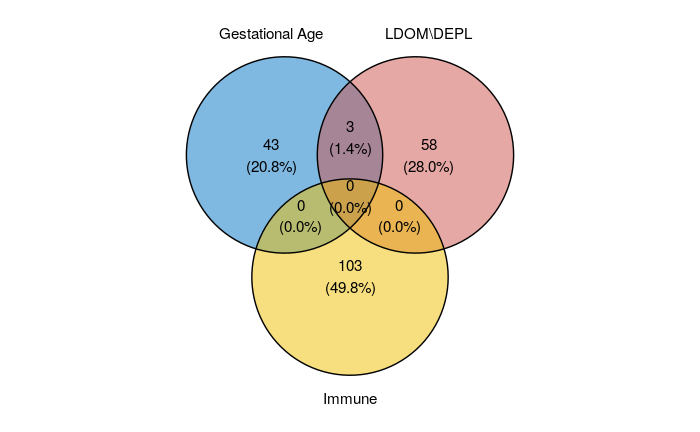

```r
immuneMarkers <- readxl::read_xlsx('../Immune Metabolic Association/CVF_ImmuneMarkers_Analysis/VMET2_DESI_NEG_Immune_LinearModels.xlsx', sheet='CVF MBL')

formatMz <- function(x) {sapply(x, FUN=function(y){format(round(y, 8), nsmall = 8)})}

immune_signature <- immuneMarkers[immuneMarkers$R2_qval < 0.05, 2]$Metabolite
# immune_signature <- immuneMarkers[immuneMarkers$R2_qval < 0.05 & immuneMarkers$R2 > 0.1, 2]$Metabolite

vmet2_immune_pos <- list(`Gestational Age`= formatMz(as.numeric(gestationalAgeSignature_vmet2)), `LDOM\\DEPL`=formatMz(as.numeric(LDeplSignature_vmet2)), Immune=formatMz(as.numeric(immune_signature)))

ggvenn(vmet2_immune_pos, fill_color = c("#0073C2FF", "#CD534CFF", "#EFC000FF"),
  stroke_size = 0.5, set_name_size = 4)
```

```r
NA
NA
```